# ISOM3390 Winter 2021 - Take Home Exam

### Task 3: Data Visualization

With all necessary data ready, first create 2 Choropleth maps for the 2016 and 2020 election results in one figure as shown by the first image posted on Canvas.

As you can see, only the 5 flipped states are colored. And colors represent differences in percentage of votes received by the 2 parties (dem vs. gop).

You need to use geospatial data available in `maps::state` and `maps::county` to draw states’ and counties’ outlines. Note that `maps::county` uses the same names for the aforementioned 4 counties as `maps::county.fips`.

Suppose that `p` is the name you to this `ggplot` object. You can directly use the code provided at the end of the following code chunk to style the plot.

Drop the chunk option `eval=F` if you want to knit the .rmd file.

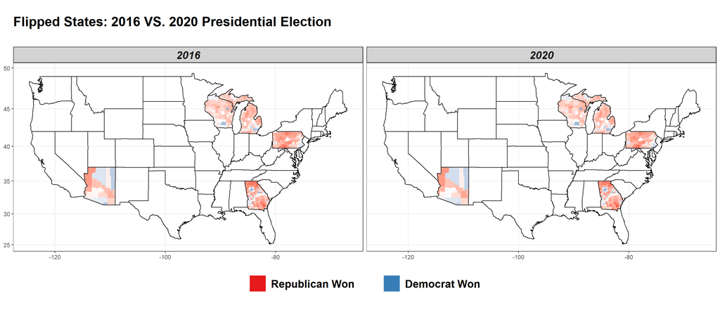

```r
# Provide your code to wrangle the data and create the plot
# You are not allowed to use any for/while/repeat loop in this chunk
# Use inner_join if you want to join two data frames

election_res_1620_plot = election_res_1620 %>%
  mutate(state_county = str_replace_all(.$state_county,c("georgia,dekalb"="georgia,de kalb","michigan,st. clair"="michigan,st clair","michigan,st. joseph"="michigan,st joseph","wisconsin,st. croix"="wisconsin,st croix"))) %>%
  inner_join(as_tibble(map_data("county")) %>%
  cbind(state_county=str_c(.$region,.$subregion,sep=",")),by="state_county") %>%
  cbind("2016"=(.$dem_2016-.$gop_2016)/.$total_2016,"2020"=(.$dem_2020-.$gop_2020)/.$total_2020) %>%
  select(c("group","long","lat","2016","2020")) %>%
  pivot_longer(c("2016","2020"))

p = ggplot(data=as_tibble(map_data("state"))) + geom_polygon(data=election_res_1620_plot,aes(long, lat, group = group, fill = value)) + coord_map() + geom_polygon(aes(long, lat, group = group), colour = "black", fill = NA) + facet_wrap(~name)

p + ggtitle("Flipped States: 2016 VS. 2020 Presidential Election \n") + theme_bw() +
  scale_fill_gradient2(name=NULL, limits = c(-1, 1),
                       low = "#e41a1c", high = "#377eb8",
                       breaks = c(-1, 1), labels = c("Republican Won        ", "Democrat Won")) +
  labs(x = NULL, y = NULL) +
  theme(legend.position = "bottom",
          strip.background = element_rect(fill="lightgray", size= 0.8),
          plot.title = element_text(size = 20, face = "bold"),
          strip.text.x = element_text(size = 16, face = "bold.italic"),
          legend.text = element_text(size = 16, face = "bold"),
          legend.spacing.x = unit(0.5, "line"),
          legend.key.size = unit(0.9, "cm")) +
    guides(fill = guide_legend(title.position = "top", title.hjust = 0.5))
```

Please also create 2 bar plots in one figure as shown by the second image posted on Canvas.

Suppose that `h` is the name you to the second `ggplot` object. You can directly use the code provided at the end of the following code chunk to style the plot.

Drop the chunk option `eval=F` if you want to knit the .rmd file.

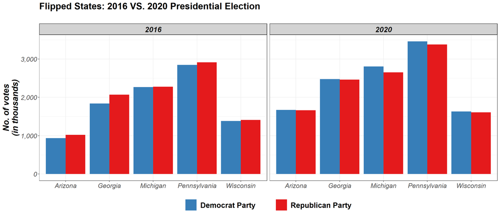

```r
# Provide your code to create the plot
# You are not allowed to use any for/while/repeat loop in this chunk

h = ggplot(election_res_1620_state, aes(x=state,y=value, fill=party)) + geom_bar(position="dodge",stat="identity") + facet_wrap(~year)

h + ggtitle("Flipped States: 2016 VS. 2020 Presidential Election \n") + theme_bw() +
  scale_y_continuous(breaks = c(0, 1000000, 2000000, 3000000),
                     labels = c("0", "1,000", "2,000", "3,000")) +
  scale_fill_manual(name=NULL, values = c("dem" = "#377eb8", "gop" = "#e41a1c"),
                    labels = c("gop"= "Republican Party", "dem"="Democrat Party        " )) +
  labs(x = NULL, y = "No. of votes\n(in thousands)") +
  theme(legend.position = "bottom",
        strip.background = element_rect(fill="lightgray", size= 0.8),
        plot.title = element_text(size = 20, face = "bold"),
        strip.text.x = element_text(size = 16, face = "bold.italic"),
        legend.text = element_text(size = 16, face = "bold"),
        legend.spacing.x = unit(0.5, "line"),
        legend.key.size = unit(0.9, "cm"),
        axis.title.y = element_text(face="bold.italic", size=18),
        axis.text.x = element_text(size = 14, face="italic"),
        axis.text.y = element_text(size = 14, face="italic")
  ) + guides(fill = guide_legend(title.position = "top", title.hjust = 0.5))
```